# **Panorama da inflação**

Os principais índices de inflação do Brasil, apontam em junho de 2020 um avanço da inflação de em média **0.71%**. Com esse resultado, no ano a inflação acumula uma variação média positiva de **1.45%**, e em 12 meses uma variação média acumulada de **3.93%**.

[output not shown]

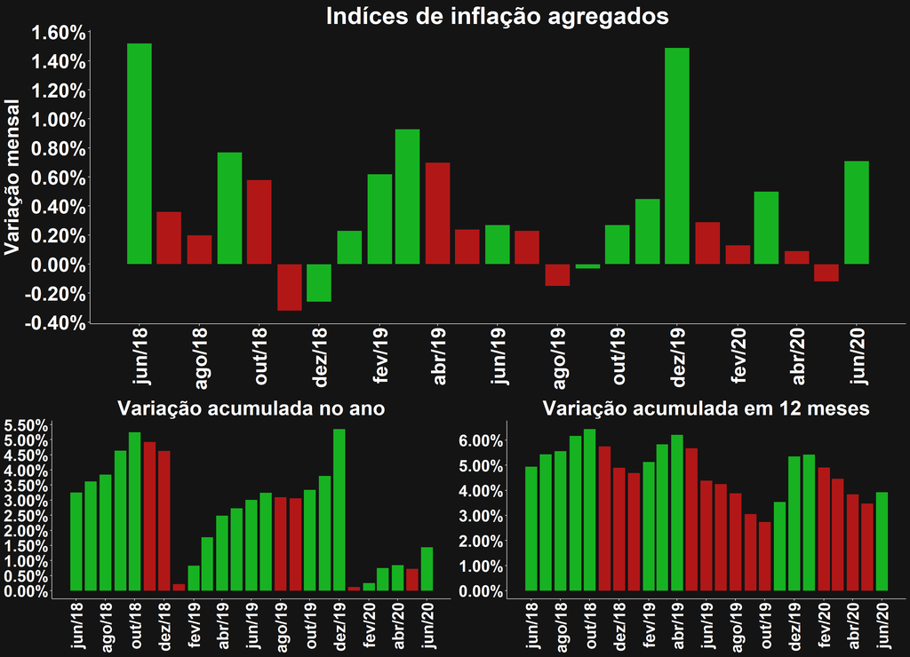

Índices selecionados para a média: IPCA, INPC e IGP-M.

# IPCA

|  | 06/2019 | 05/2020 | 06/2020 |
| --- | --- | --- | --- |
| Variação mensal | 0.01% | -0.38% | 0.26% |
| Variação acumulada no ano | 2.23% | -0.16% | 0.1% |
| Variação acumulada em 12 meses | 3.37% | 1.88% | 2.13% |

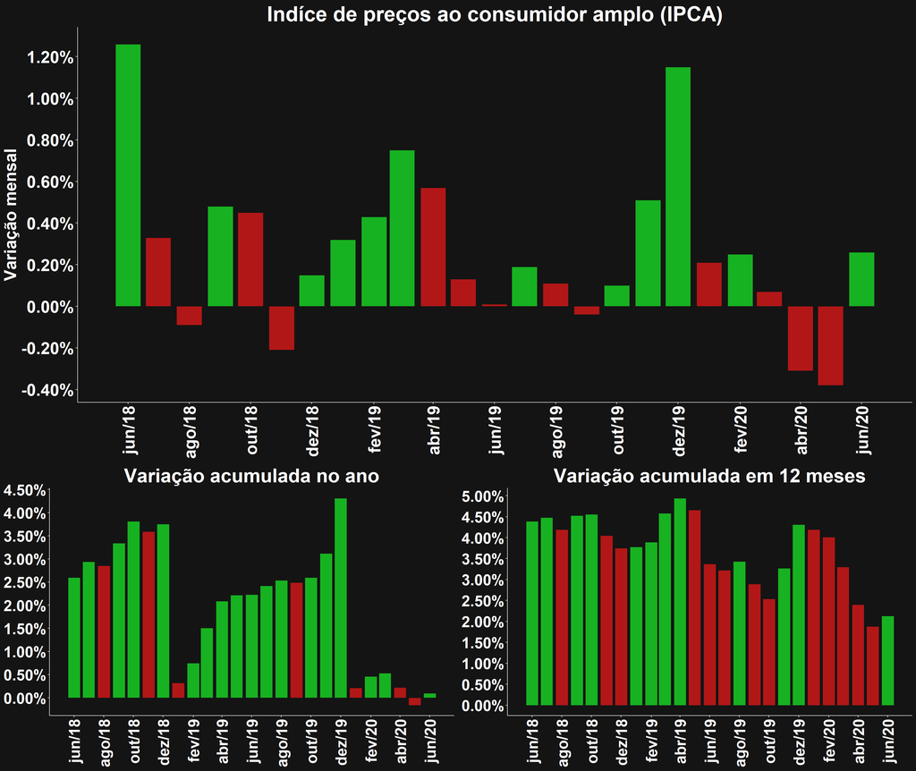

Os grupos que tiveram maior resultado positivo foram Artigos de residência (1.3%) e Comunicação (0.75%), e negativo Vestuário (-0.46%) e Despesas pessoais (-0.05%).

|  | Variação mensal | Variação acumulada no ano | Peso mensal |
| --- | --- | --- | --- |
| Alimentação e bebidas | 0.38% | 4.1% | 20.09% |
| Habitação | 0.04% | -0.02% | 15.6% |
| Artigos de residência | 1.3% | -0.74% | 3.68% |
| Vestuário | -0.46% | -1.93% | 4.52% |
| Transportes | 0.31% | -4.99% | 19.55% |
| Saúde e cuidados pessoais | 0.35% | 0.65% | 13.59% |
| Despesas pessoais | -0.05% | 0.2% | 10.78% |
| Educação | 0.05% | 4.55% | 6.43% |
| Comunicação | 0.75% | 1.16% | 5.75% |

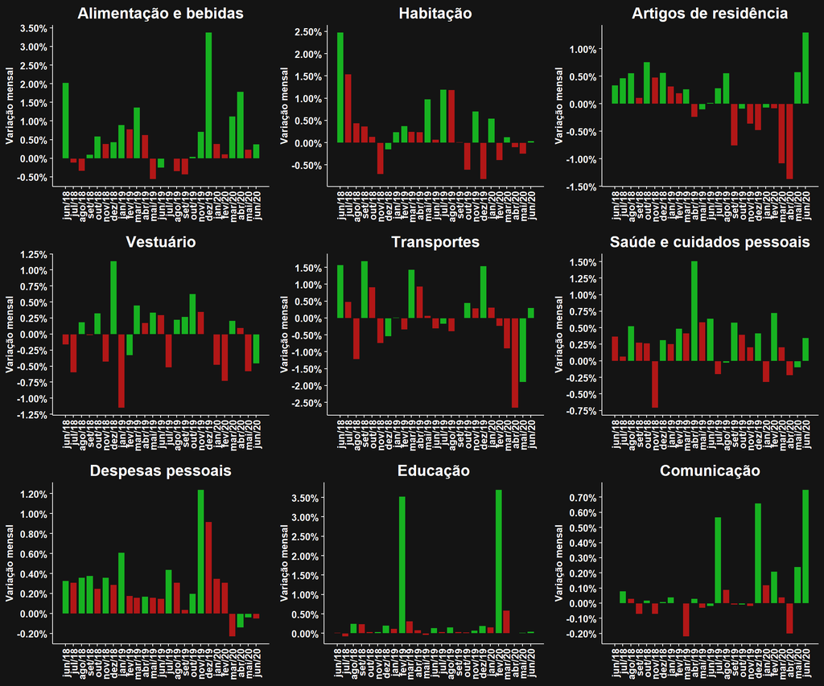

A nível de sub-itens os que mais influenciaram positivamente no resultado em relação ao seu peso foram Gasolina (3.24%%) e Etanol (5.74%%), e negativamente Passagem aérea (-26.01%%) e Tomate (-15.04%%).

|  | Variação mensal | Variação acumulada no ano | Peso mensal |
| --- | --- | --- | --- |
| Etanol | 5.74% | -13.43% | 0.55% |
| Gasolina | 3.24% | -11.87% | 4.41% |
| Combo de telefonia, internet e tv por assinatura | 1.44% | 1.44% | 1.71% |
| Plano de saúde | 0.6% | 3.64% | 4.15% |

|  | Variação mensal | Variação acumulada no ano | Peso mensal |
| --- | --- | --- | --- |
| Transporte por aplicativo | -13.95% | -17.42% | 0.21% |
| Tomate | -15.04% | 19.52% | 0.25% |
| Passagem aérea | -26.01% | -55.13% | 0.42% |
| Perfume | -3.52% | -3.1% | 1.06% |

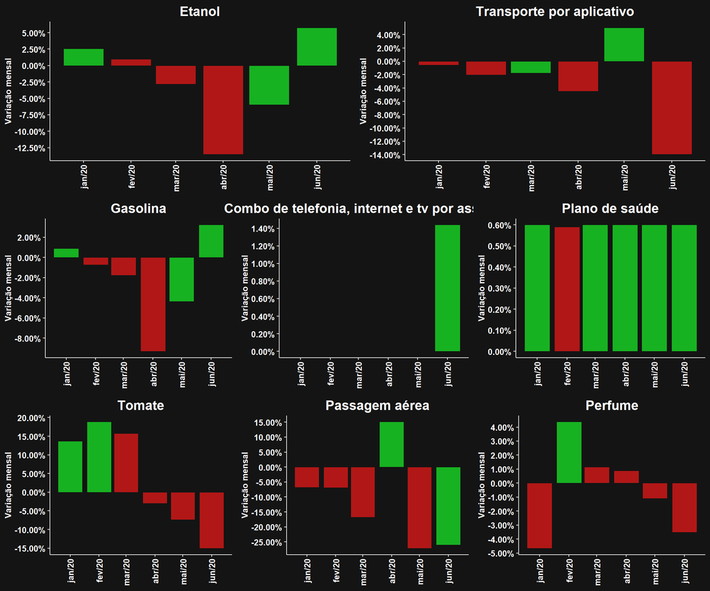

# INPC

|  | 06/2019 | 05/2020 | 06/2020 |
| --- | --- | --- | --- |
| Variação mensal | 0.01% | -0.25% | 0.3% |
| Variação acumulada no ano | 2.45% | 0.06% | 0.36% |
| Variação acumulada em 12 meses | 3.31% | 2.05% | 2.35% |

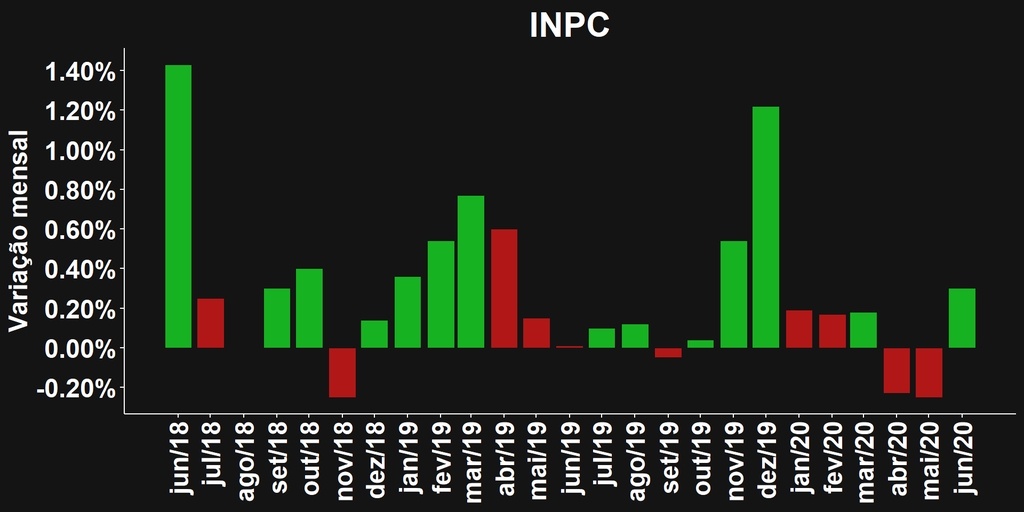

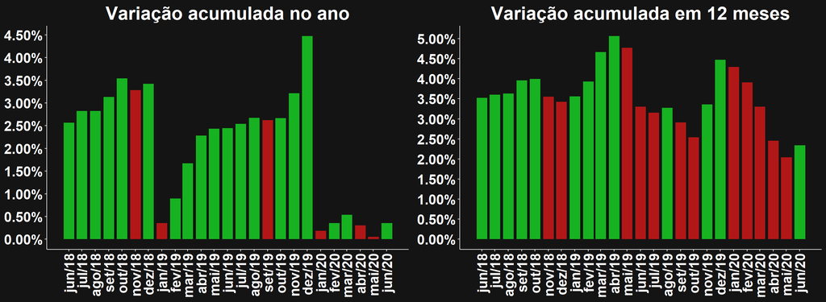

# IGP-M

O Indíce Geral de Preços de Mercado (IGP-M) variou 1.56% em junho, valor superior ao mesmo período do ano anterior quando apresentou uma taxa de 0.8%. Com esse resultado o indíce acumula no ano uma variação positiva de 3.89%, e em 12 meses uma variação positiva de 7.31%.

|  | 06/2019 | 05/2020 | 06/2020 |
| --- | --- | --- | --- |
| Variação mensal | 0.8% | 0.28% | 1.56% |
| Variação acumulada no ano | 4.37% | 2.3% | 3.89% |
| Variação acumulada em 12 meses | 6.51% | 6.51% | 7.31% |

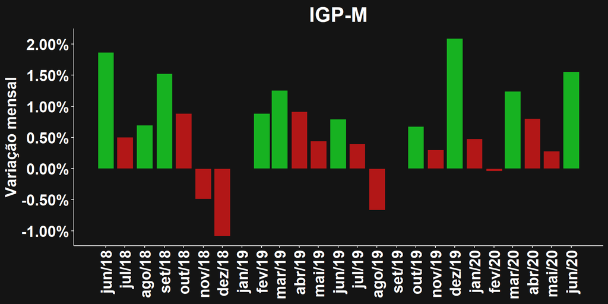

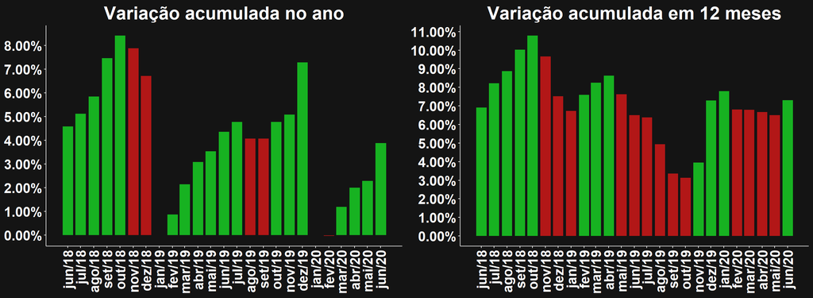

# IGP-DI

O Indíce Geral de Preços - Disponibilidade Interna (IGP-DI) variou 1.6% em junho, valor superior ao mesmo período do ano anterior quando apresentou uma taxa de 0.63%. Com esse resultado o indíce acumula no ano uma variação positiva de 4.44%, e em 12 meses uma variação positiva de 7.84%.

|  | 06/2019 | 05/2020 | 06/2020 |
| --- | --- | --- | --- |
| Variação mensal | 0.63% | 1.07% | 1.6% |
| Variação acumulada no ano | 4.33% | 2.8% | 4.44% |
| Variação acumulada em 12 meses | 6.04% | 6.81% | 7.84% |

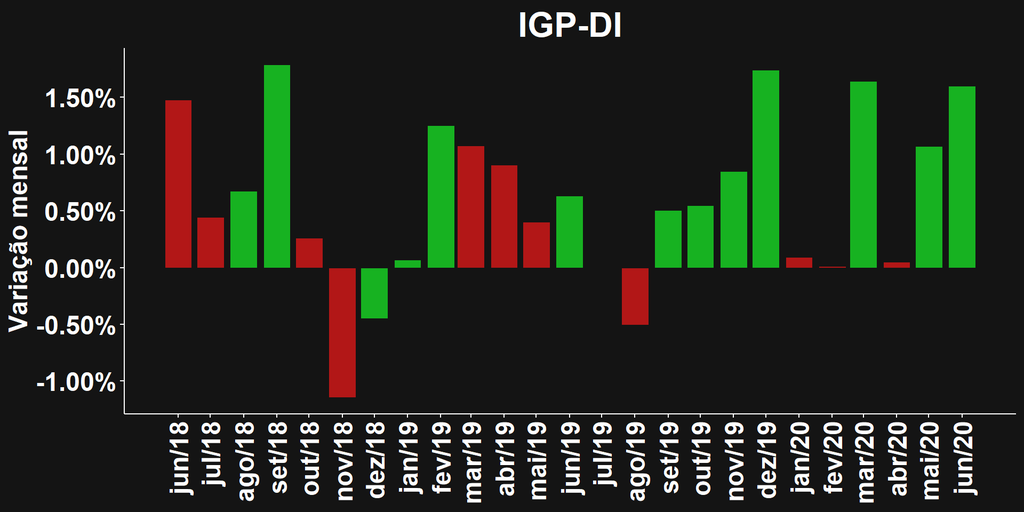

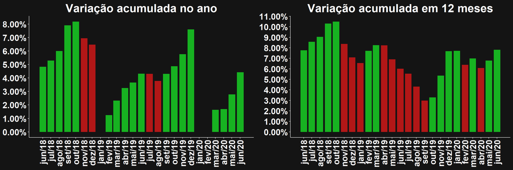

[output not shown]

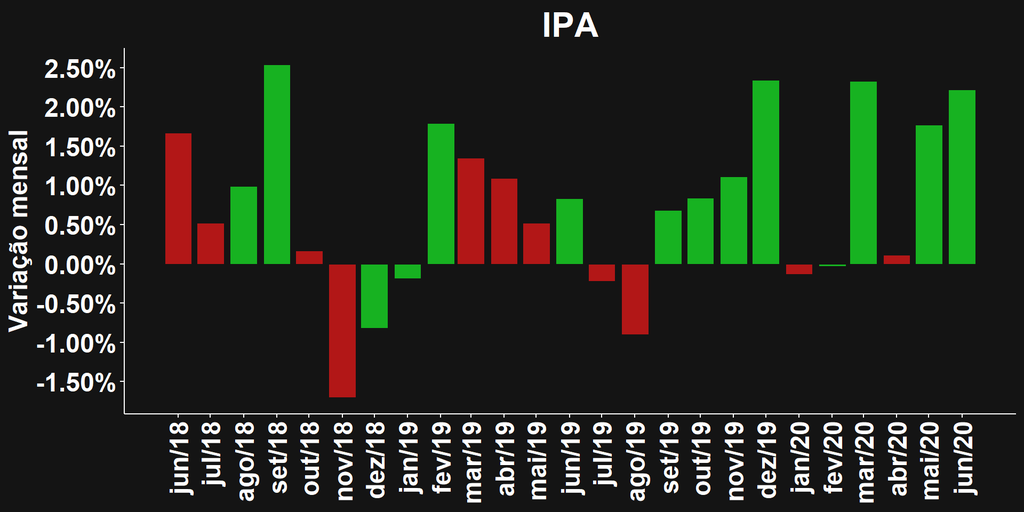

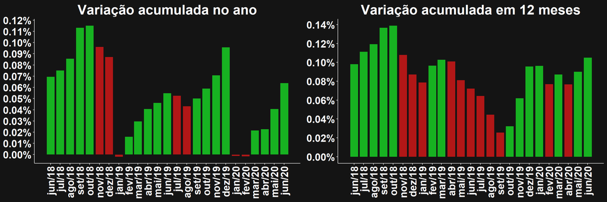

O Indíce de Preços ao Consumidor (IPC), integrante do IGP-DI com peso de 30%, apresentou variação de 0.36% em junho, valor superior ao mesmo período do ano anterior quando apresentou uma taxa de -0.02%. Com esse resultado o indíce acumula no ano uma variação negativa de -0.03%, e em 12 meses uma variação positiva de 2.22%.

|  | 06/2019 | 05/2020 | 06/2020 |
| --- | --- | --- | --- |
| Variação mensal | -0.02% | -0.54% | 0.36% |
| Variação acumulada no ano | 1.84% | -0.39% | -0.03% |
| Variação acumulada em 12 meses | 3.73% | 1.83% | 2.22% |

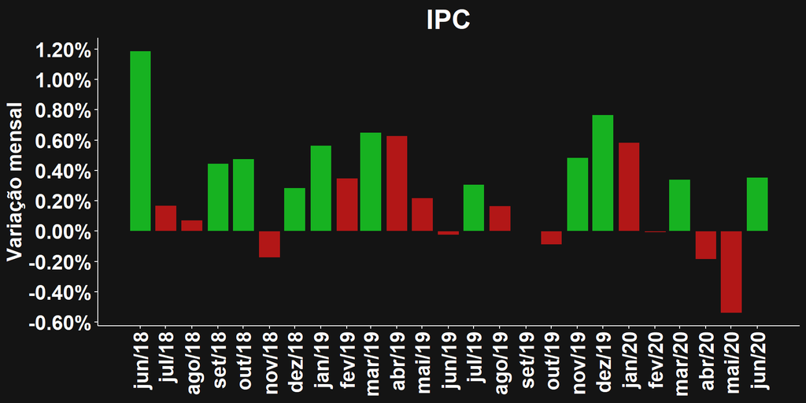

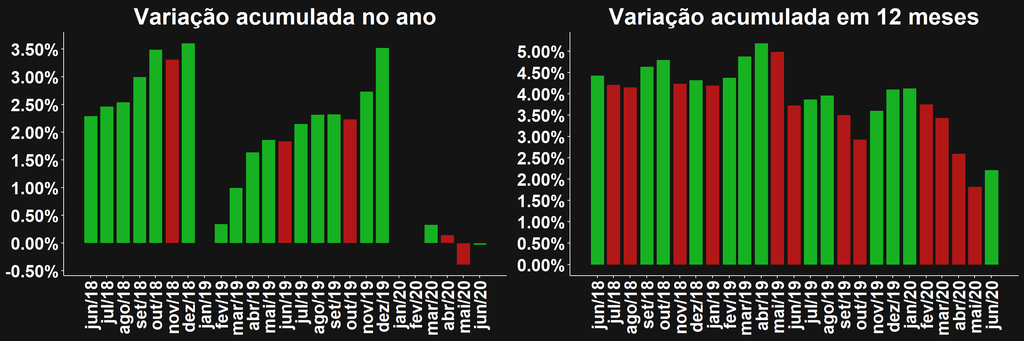

|  | 06/2019 | 05/2020 | 06/2020 |
| --- | --- | --- | --- |
| Variação mensal | 0.88% | 0.2% | 0.34% |
| Variação acumulada no ano | 1.71% | 1.01% | 1.35% |
| Variação acumulada em 12 meses | 3.86% | 4.24% | 3.68% |

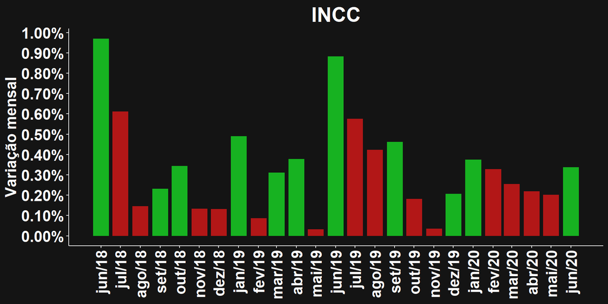

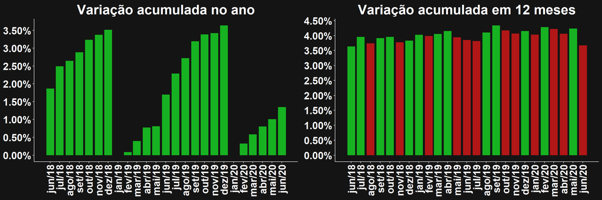

# Estatísticas

As estatísticas descritivas a seguir são feitas com base nos últimos 48 meses, e tem como objetivo possibilitar a avaliação do resultado observado em comparação aos períodos anteriores.

|  | Minimo | 1 Quartil | Mediana | Media | 3 Quartil | Maximo | Desvio Padrão |
| --- | --- | --- | --- | --- | --- | --- | --- |
| IPCA | -0.38% | 0.12% | 0.26% | 0.26% | 0.41% | 1.26% | 0.3% |
| INPC | -0.3% | 0.08% | 0.18% | 0.24% | 0.36% | 1.43% | 0.32% |
| IGP-M | -1.1% | 0.06% | 0.46% | 0.4% | 0.8% | 2.09% | 0.71% |
| IGP-DI | -1.24% | 0.05% | 0.43% | 0.41% | 0.84% | 1.79% | 0.73% |
| IPA | -1.96% | -0.12% | 0.51% | 0.46% | 1.09% | 2.54% | 1.08% |
| IPC | -0.54% | 0.13% | 0.32% | 0.28% | 0.45% | 1.19% | 0.3% |
| INCC | -0.02% | 0.18% | 0.31% | 0.32% | 0.39% | 0.97% | 0.22% |

Levando em consideração o desvio padrão de cada indíce, proporcionalmente os que mais se afastaram da média foram o IGP-M, o IGP-DI e o IPA.

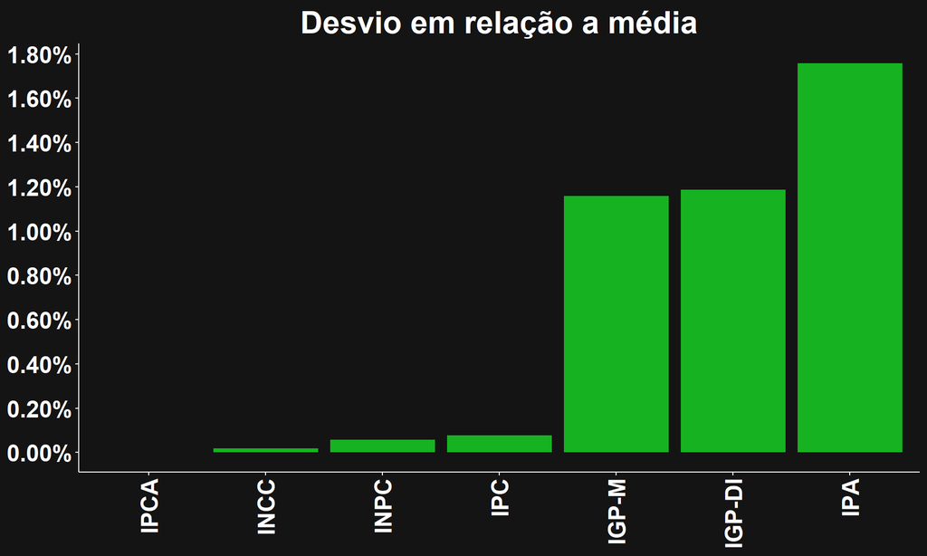

**João Victor Gomes**  
**jvg.santana@gmail.com**  
**[linkedin.com/in/jvictorgomes](https://www.linkedin.com/in/jvictorgomes/)**